# Exploring and Analyzing Netflix Show User Reviews

### 4.1.3 Year of Release:

Netflix has a wide range of films on their platform. Below is a graphical representation of the distributions of content by original release date, separated by both Movies and TV Shows.

**Netflix Movie content by Release Year**

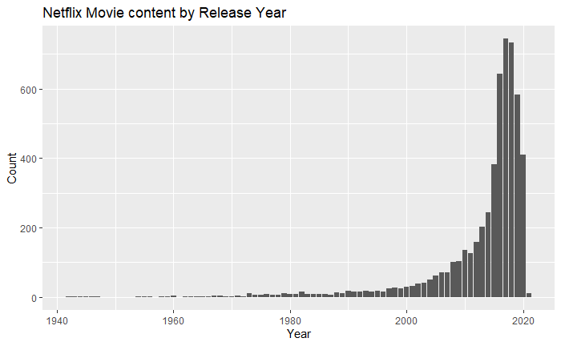

```r
netflixshows%>%
  group_by(release_year)%>%
  filter(release_year != "" & release_year != is.na(release_year))%>%
  filter(type == "Movie")%>%
  ggplot()+
    geom_bar(mapping = aes(
      x = release_year))+
      labs(
          title = "Netflix Movie content by Release Year",
          x = "Year",
          y = "Count"
        )
```

```r
netflixshows%>%
  group_by(release_year)%>%
  filter(release_year != "" |  !is.na(release_year))%>%
  filter(type == "Movie")%>%
  ungroup()%>%
  count(release_year, name = "Count")
```

| release_year | Count |
| --- | --- |
| 1942 | 2 |
| 1943 | 3 |
| 1944 | 3 |
| 1945 | 3 |
| 1946 | 1 |
| 1947 | 1 |
| 1954 | 2 |
| 1955 | 3 |
| 1956 | 2 |
| 1958 | 3 |

[output cut: 62 more lines]

**Netflix TV Show content by Release Year**

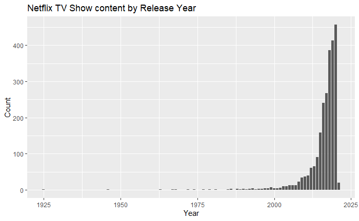

```r
netflixshows%>%
  group_by(release_year)%>%
  filter(release_year != "" & release_year != is.na(release_year))%>%
  filter(type == "TV Show")%>%
  ggplot()+
    geom_bar(mapping = aes(
      x = release_year
     ))+
      labs(
          title = "Netflix TV Show content by Release Year",
          x = "Year",
          y = "Count"
        )
```

```r
netflixshows%>%
  group_by(release_year)%>%
  filter(release_year != ""  & release_year != is.na(release_year))%>%
  filter(type == "TV Show")%>%
  ungroup()%>%
  count(release_year, name = "Count")
```

| release_year | Count |
| --- | --- |
| 1925 | 1 |
| 1946 | 1 |
| 1963 | 1 |
| 1967 | 1 |
| 1968 | 1 |
| 1972 | 1 |
| 1974 | 1 |
| 1977 | 1 |
| 1979 | 1 |
| 1981 | 1 |

[output cut: 36 more lines]

### 4.1.4 Age Rating:

Netflix rates all of their shows in a way that suggests appropriate ages see appropriate material. The graph below demonstrates the distribution between Netflix’s content and the associating Age rating.

**Netflix Content by Age Rating**

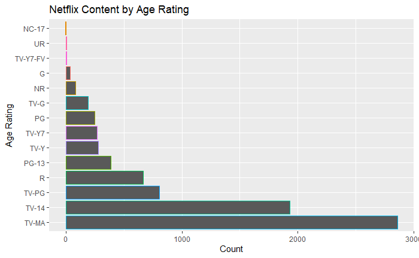

```r
netflixshows%>%
  group_by(rating)%>%
  filter(rating != "" & rating != is.na(rating))%>%
  count(.)%>%
  ggplot()+
  geom_bar(stat = "identity",mapping = aes(
    y = reorder(rating, -n),
    x = n,
    color = rating),show.legend = F)+
    labs(
        title = "Netflix Content by Age Rating",
        x = "Count",
        y = "Age Rating"
      )
```

```r
netflixshows%>%
  group_by(rating)%>%
  filter(rating != "" & rating != is.na(rating))%>%
  count(., name = "Number of Entries")
```

| rating | Number of Entries |
| --- | --- |
| G | 39 |
| NC-17 | 3 |
| NR | 84 |
| PG | 247 |
| PG-13 | 386 |
| R | 665 |
| TV-14 | 1931 |
| TV-G | 194 |
| TV-MA | 2863 |
| TV-PG | 806 |

[output cut: 4 more lines]

```r
NA
```

### 4.1.5 Genre Type:

Netflix has a wide arrange of genres to choose from. This is what makes their platform so enjoyable by any age! Below is a graphical representation of the distribution of Netflix Genre Content. As before, they are separated by either Movies or TV Shows.

**Netflix Movie Content by Genre**

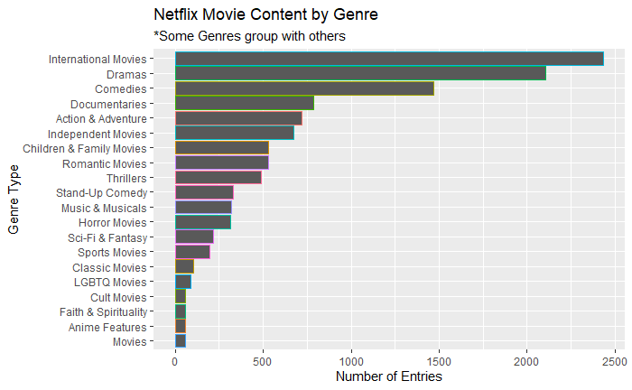

```r
netflixshows%>%
  filter(type == "Movie")%>%
  separate_rows(listed_in, sep = ", ")%>%
  group_by(listed_in)%>%
  summarize(listed_in)%>%
  count(.)%>%
  ggplot(mapping = aes(
    x = n,
    y = reorder(listed_in,n),
    color = listed_in))+
geom_bar(stat = "identity", show.legend = F)+
  labs(
    title = "Netflix Movie Content by Genre",
    subtitle = "*Some Genres group with others",
    x= "Number of Entries",
    y = "Genre Type"
  )
```

```r
netflixshows%>%
  filter(type == "Movie")%>%
  separate_rows(listed_in, sep = ", ")%>%
  group_by(listed_in)%>%
  summarize(listed_in)%>%
  count(.)
```

| listed_in | n |
| --- | --- |
| Action & Adventure | 721 |
| Anime Features | 57 |
| Children & Family Movies | 532 |
| Classic Movies | 103 |
| Comedies | 1471 |
| Cult Movies | 59 |
| Documentaries | 786 |
| Dramas | 2106 |
| Faith & Spirituality | 57 |
| Horror Movies | 312 |

[output cut: 10 more lines]

**Netflix TV Show Content by Genre**

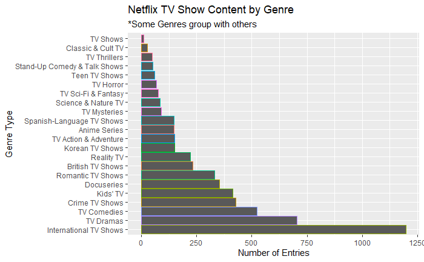

```r
netflixshows%>%
  filter(type == "TV Show")%>%
  separate_rows(listed_in, sep = ", ")%>%
  group_by(listed_in)%>%
  summarize(listed_in)%>%
  count(.)%>%
  ggplot(mapping = aes(
    x = n,
    y = reorder(listed_in, -n),
    color = listed_in))+
geom_bar(stat = "identity",show.legend = F)+
  labs(
    title = "Netflix TV Show Content by Genre",
    subtitle = "*Some Genres group with others",
    x= "Number of Entries",
    y = "Genre Type"
  )
```

```r
netflixshows%>%
  filter(type == "TV Show")%>%
  separate_rows(listed_in, sep = ", ")%>%
  group_by(listed_in)%>%
  summarize(listed_in)%>%
  count(.)
```

| listed_in | n |
| --- | --- |
| Anime Series | 148 |
| British TV Shows | 232 |
| Classic & Cult TV | 27 |
| Crime TV Shows | 427 |
| Docuseries | 353 |
| International TV Shows | 1199 |
| Kids' TV | 414 |
| Korean TV Shows | 150 |
| Reality TV | 222 |
| Romantic TV Shows | 333 |

[output cut: 12 more lines]

### 4.1.6 Directors:

Netflix likes to hire directors over and over if they keep pumping out content that is popular. Below is a graphical representation of the top 10 directors featured on Netflix and the number of entries they released, both for Movies and TV Shows.

**Netflix Movie Content by Director**

[figure not shown]

```r
netflixshows%>%
  filter(director != is.na(director) & director != "" & type == "Movie")%>%
  group_by(director)%>%
  summarize(director)%>%
  count(.)%>%
  arrange(desc(n))%>%
  head(., n = 10)%>%
  ggplot(mapping = aes(
    y = reorder(director, -n),
    x = n,
    color = director))+
  geom_bar(stat = "identity",show.legend = F)+
  labs(
    title = "Top 10 Netflix Movie Directors",
    y = "Director name",
    x = "Number of Movies on Netflix")
```

```r
NA
NA
```

**Netflix TV Show Content by Director**

[figure not shown]

```r
netflixshows%>%
  filter(director != is.na(director) & director != "" & type == "TV Show")%>%
  group_by(director)%>%
  summarize(director)%>%
  count(.)%>%
  arrange(desc(n))%>%
  head(10)%>%
  ggplot(mapping = aes(
    y = reorder(director, -n),
    x = n,
    color = director))+
  geom_bar(stat = "identity",show.legend = F)+
  labs(
    title = "Top 10 Netflix TV Show Directors",
    y = "Director name",
    x = "Number of TV Shows on Netflix")
```

```r
NA
NA
```

# 5 Data Analysis:

## 5.1 Analysizing Data with 2 or more variables:

Comparing Data to itself is the most important factor when it comes to data analysis; how does Data A have a relationship to Data B?

### 5.1.1 Most Genres per Country:

Each Country has their own favorite type of Genre. Below is a graphical representation of the relationship between Genres and associating countries. The data is separated by content type, either “Movie” or “TV Show”. A graph like this is helpful to answer questions such as:

1. What genre does each country prefer?
2. Which country has the most of that particular genre?
3. What is the target audience per country?
4. Is Netflix showing appropriate content genres per country?

**Netflix Movie Genre Content by Country**

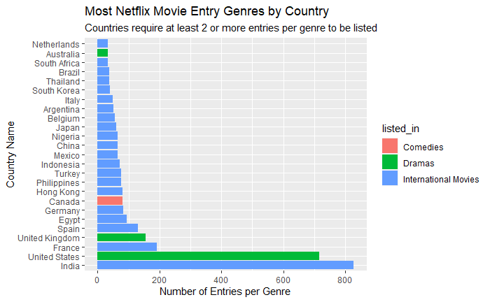

```r
netflixshows%>%
  separate_rows(country, sep = ", ")%>%
  separate_rows(listed_in, sep = ", ")%>%
  filter(type == "Movie" & country != "" & country != is.na(country))%>%
  group_by(country)%>%
  count(listed_in, name = "Genres")%>%
  filter(Genres == max(Genres) & Genres >= 2)%>%
  arrange(desc(Genres))%>%
  head(25)%>%
  ggplot(mapping = aes(
    x = Genres,
    y = reorder(country, -Genres),
    fill = listed_in
  ))+
  geom_histogram(stat = "identity")+
  labs(
    title = "Most Netflix Movie Entry Genres by Country",
    subtitle = "Countries require at least 2 or more entries per genre to be listed",
    x = "Number of Entries per Genre",
    y = "Country Name"
  )
```

```r
netflixshows%>%
  separate_rows(country, sep = ", ")%>%
  separate_rows(listed_in, sep = ", ")%>%
  filter(type == "Movie" & country != "" & country != is.na(country))%>%
  group_by(country)%>%
  count(listed_in, name = "Genres")%>%
  filter(Genres == max(Genres) & Genres >= 2)%>%
  arrange(desc(Genres))%>%
  head(25)
```

| country | listed_in | Genres |
| --- | --- | --- |
| India | International Movies | 828 |
| United States | Dramas | 716 |
| France | International Movies | 191 |
| United Kingdom | Dramas | 156 |
| Spain | International Movies | 130 |
| Egypt | International Movies | 95 |
| Germany | International Movies | 82 |
| Canada | Comedies | 81 |
| Hong Kong | International Movies | 81 |
| Philippines | International Movies | 77 |

[output cut: 15 more lines]

**Netflix TV Show Genre Content by Country**

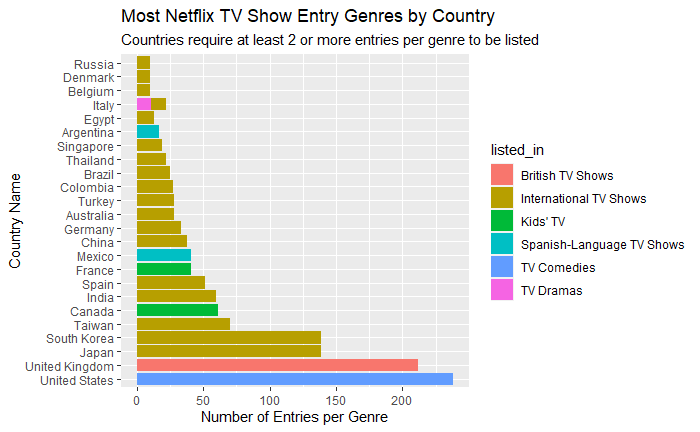

```r
netflixshows%>%
  separate_rows(country, sep = ", ")%>%
  separate_rows(listed_in, sep = ", ")%>%
  filter(type == "TV Show" & country != "" & country != is.na(country))%>%
  group_by(country)%>%
  count(listed_in, name = "Genres")%>%
  filter(Genres == max(Genres) & Genres >= 2)%>%
  arrange(desc(Genres))%>%
  head(25)%>%
  ggplot(mapping = aes(
    x = Genres,
    y = reorder(country, -Genres),
    fill = listed_in
  ))+
  geom_histogram(stat = "identity")+
  labs(
    title = "Most Netflix TV Show Entry Genres by Country",
    subtitle = "Countries require at least 2 or more entries per genre to be listed",
    x = "Number of Entries per Genre",
    y = "Country Name"
  )
```

```r
netflixshows%>%
  separate_rows(country, sep = ", ")%>%
  separate_rows(listed_in, sep = ", ")%>%
  filter(type == "TV Show" & country != "" & country != is.na(country))%>%
  group_by(country)%>%
  count(listed_in, name = "Genres")%>%
  filter(Genres == max(Genres) & Genres >= 2)%>%
  arrange(desc(Genres))%>%
  head(25)
```

| country | listed_in | Genres |
| --- | --- | --- |
| United States | TV Comedies | 238 |
| United Kingdom | British TV Shows | 212 |
| Japan | International TV Shows | 139 |
| South Korea | International TV Shows | 139 |
| Taiwan | International TV Shows | 70 |
| Canada | Kids' TV | 61 |
| India | International TV Shows | 60 |
| Spain | International TV Shows | 51 |
| France | Kids' TV | 41 |
| Mexico | Spanish-Language TV Shows | 41 |

[output cut: 15 more lines]

1. What Rating is most appropriate per country?
2. What age group is most prevalent per country?
3. Does Netflix prefer to target older or younger audiences?

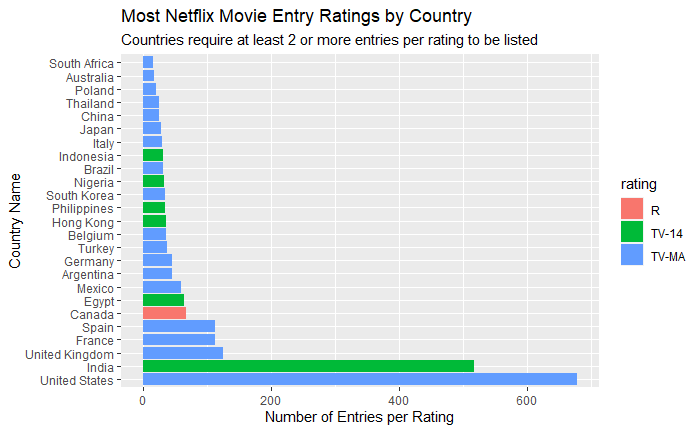

```r
netflixshows%>%
  separate_rows(country, sep = ", ")%>%
  filter(type == "Movie" & country != "" & country != is.na(country))%>%
  group_by(country)%>%
  count(rating, name = "RatingN")%>%
  filter(RatingN == max(RatingN) & RatingN >= 2)%>%
  arrange(desc(RatingN))%>%
  head(25)%>%
  ggplot(mapping = aes(
    x = RatingN,
    y = reorder(country, -RatingN),
    fill = rating
  ))+
  geom_histogram(stat = "identity")+
  labs(
    title = "Most Netflix Movie Entry Ratings by Country",
    subtitle = "Countries require at least 2 or more entries per rating to be listed",
    x = "Number of Entries per Rating",
    y = "Country Name")
```

```r
netflixshows%>%
  separate_rows(country, sep = ", ")%>%
  filter(type == "Movie" & country != "" & country != is.na(country))%>%
  group_by(country)%>%
  count(rating, name = "RatingN")%>%
  filter(RatingN == max(RatingN) & RatingN >= 2)%>%
  arrange(desc(RatingN))%>%
  head(25)
```

| country | rating | RatingN |
| --- | --- | --- |
| United States | TV-MA | 678 |
| India | TV-14 | 518 |
| United Kingdom | TV-MA | 126 |
| France | TV-MA | 113 |
| Spain | TV-MA | 113 |
| Canada | R | 68 |
| Egypt | TV-14 | 64 |
| Mexico | TV-MA | 60 |
| Argentina | TV-MA | 46 |
| Germany | TV-MA | 46 |

[output cut: 15 more lines]

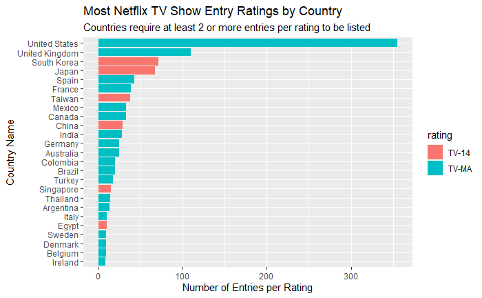

```r
netflixshows%>%
  separate_rows(country, sep = ", ")%>%
  filter(type == "TV Show" & country != "" & country != is.na(country))%>%
  group_by(country)%>%
  count(rating, name = "RatingN")%>%
  filter(RatingN == max(RatingN) & RatingN >= 2)%>%
  arrange(desc(RatingN))%>%
  head(25)%>%
  ggplot(mapping = aes(
    x = RatingN,
    y = reorder(country,RatingN),
    fill = rating
  ))+
  geom_histogram(stat = "identity")+
  labs(
    title = "Most Netflix TV Show Entry Ratings by Country",
    subtitle = "Countries require at least 2 or more entries per rating to be listed",
    x = "Number of Entries per Rating",
    y = "Country Name")
```

```r
netflixshows%>%
  separate_rows(country, sep = ", ")%>%
  filter(type == "TV Show" & country != "" & country != is.na(country))%>%
  group_by(country)%>%
  count(rating, name = "RatingN")%>%
  filter(RatingN == max(RatingN) & RatingN >= 2)%>%
  arrange(desc(RatingN))%>%
  head(25)
```

| country | rating | RatingN |
| --- | --- | --- |
| United States | TV-MA | 355 |
| United Kingdom | TV-MA | 110 |
| South Korea | TV-14 | 71 |
| Japan | TV-14 | 67 |
| Spain | TV-MA | 43 |
| France | TV-MA | 39 |
| Taiwan | TV-14 | 38 |
| Canada | TV-MA | 33 |
| Mexico | TV-MA | 33 |
| China | TV-14 | 29 |

[output cut: 15 more lines]

# 6 Conclusion

# 7 Citations

Special Thanks to [Shivam Bansal](https://www.kaggle.com/shivamb) for providing the Netflix Dataset, which can be found [Here!](https://www.kaggle.com/shivamb/netflix-shows')